# ALGORITMA MACHINE LEARNING : USECASE 2 - FRAUD DETECTION

# Background

Problem yang ada yaitu banyak terdapat perubahan pola-pola fraud SLI (panggilan internasional) baru, sehingga semakin banyak pola fraud yang tidak lagi bisa dideteksi dengan menggunakan **rule base**. Dengan memanfaatkan capability AI/ML, maka diharapkan bisa meningkatkan (enhance) **FRAMES**.

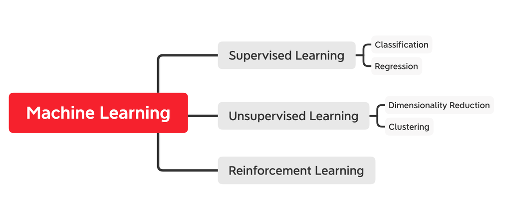

Dengan memanfaatkan salah satu dari 3 (tiga) kategori **Machine Learning** yaitu **Unsupervised Learning** untuk mendeteksi fraud. Hal ini dilakukan karena data yang digunakan tidak memiliki variabel target, sehingga kita akan membiarkan mesin yang mempelajari data tersebut. Selain itu tujuan dari analisa ini yaitu bisa menampilkan informasi tersembunyi dari data yang dapat berguna untuk mendeteksi anomali data. Model yang digunakan yaitu **Anomaly Detection**.

# Import Libraries

Seperti biasa, sebelum memulai analisa dan modeling, lakukan import beberapa library terkait yang dibutuhkan untuk dikerjakan pada data.

```python
# Data Analysis
import pandas as pd
import numpy as np
from joblib import dump, load
pd.set_option('display.max_columns', 10)

# Visualization
import matplotlib.pyplot as plt
import plotly
import plotly.express as px
from pylab import rcParams
plt.style.use('seaborn')

# Info cell
import time
import warnings
from tqdm import tqdm
warnings.filterwarnings('ignore')

# Modeling
from sklearn import preprocessing, svm
from sklearn.preprocessing import StandardScaler
from sklearn.decomposition import PCA
from sklearn.covariance import EllipticEnvelope
from sklearn.ensemble import IsolationForest
from sklearn.manifold import TSNE

# Magic function
%load_ext autoreload
%load_ext autotime
%autoreload 2
%config IPCompleter.greedy=True
%matplotlib inline
```

[output not shown]

# Data Load and Understanding

Dataset yang digunakan untuk analisa ada 2 (dua) dengan rentang waktu pengambilan data transaksi selama 1 (satu) bulan, pada bulan maret. Dataset yang dimaksud disimpan ke dalam file, dengan keterangan sebagai berikut :

- **fraud_pstn_202003.csv** : Data kotor transaksi telepon SLI selama 1 (satu) bulan pada bulan maret 2020.
- **fraud_pst_maret2020_label1.xlsx** : Data fraud transaksi telepon SLI selama bulan maret dengan rule base.

Dataset memiliki nama kolom dengan deskripsi sebagai berikut :

- `start` : Tanggal dan jam panggilan telepon dimulai
- `end` : Tanggal dan jam panggilan telepon selesai
- `source_num` : Nomor telepon asal
- `dest_num` : Nomor telepon tujuan
- `access_code` : Kode akses yang digunakan untuk panggilan SLI
- `org_dest_num` : Kode kelompok nomor telepon tujuan
- `duration` : Lama panggilan telepon dalam detik
- `dest_country` : Nama negara tujuan telepon
- `dest_country_status` : Status kategori dari negara tujuan telepon (COMMON, BLACKLIST, dan WHITELIST)

Dataset yang digunakan bisa diakses pada link google drive berikut ini :

https://drive.google.com/drive/folders/1sFR3uGfThCCJA6IlhomeKntaJKHBUYhO?usp=sharing

```python
colname = ['start','end','source_num', 'dest_num', 'access_code', 'org_dest_num', 'duration', 'dest_country', 'dest_country_status']
data = pd.read_csv('dataset/fraud_pstn_202003.csv', sep='\t', names=colname, parse_dates=['start', 'end'])
fraud = pd.read_excel('dataset/fraud_pst_maret2020_label1.xlsx')
```

```
time: 2.56 s
```

```python
data.head()
```

|  | start | end | source_num | dest_num | access_code | org_dest_num | duration | dest_country | dest_country_status |
| --- | --- | --- | --- | --- | --- | --- | --- | --- | --- |
| 0 | 2020-03-04 11:18:48 | 2020-03-04 11:20:40 | 315470709 | 61298799842 | 1017.0 | 10176129 | 100.0 | AUSTRALIA | WHITELIST |
| 1 | 2020-03-04 10:07:10 | 2020-03-04 10:31:58 | 2150862540 | 02129974855 | NaN | 21299748 | 1487.0 | NaN | NaN |
| 2 | 2020-03-04 11:23:04 | 2020-03-04 11:28:34 | 254669100 | 81662238903 | 1017.0 | 10178166 | 319.0 | JAPAN | WHITELIST |
| 3 | 2020-03-04 10:33:15 | 2020-03-04 10:33:19 | 2130069819 | 41794943375 | 7.0 | 7417949 | 0.0 | SWITZERLAND | BLACKLIST |
| 4 | 2020-03-04 10:38:14 | 2020-03-04 10:39:23 | 215265506 | 886227990858 | 1017.0 | 10178862 | 67.0 | TAIWAN | WHITELIST |

```
time: 53.5 ms
```

```python
fraud.head()
```

|  | LAST_UPDATE | CALL_DATE | source_num | dest_num | TOTAL_CALL | TOTAL_DURATION | DESTINATION | LAST_TRUNKIN | LAST_TRUNKOUT | CDRSOURCE | TRUNKIN_OWNER | TRUNKOUT_OWNER |
| --- | --- | --- | --- | --- | --- | --- | --- | --- | --- | --- | --- | --- |
| 0 | 01-MAR-20 16:38:05 | 01-MAR-20 00:00:00 | 2129185200 | 88233011407 | 12 | 5478 | SATELITE THURAYA | BDJK1G | GCTHKS | GB_JKT | TELKOM | TELIN HK SILVER |
| 1 | 01-MAR-20 16:38:05 | 01-MAR-20 00:00:00 | 2129185200 | 88233011410 | 10 | 3716 | SATELITE THURAYA | BDJK1G | GCTHKS | GB_JKT | TELKOM | TELIN HK SILVER |
| 2 | 01-MAR-20 16:38:05 | 01-MAR-20 00:00:00 | 2129185200 | 88236900059 | 7 | 2789 | SATELITE THURAYA | BDJK1G | GCTHKS | GB_JKT | TELKOM | TELIN HK SILVER |
| 3 | 01-MAR-20 16:38:05 | 01-MAR-20 00:00:00 | 2129185200 | 88236900070 | 8 | 3709 | SATELITE THURAYA | BDJK1G | GCTHKS | GB_JKT | TELKOM | TELIN HK SILVER |
| 4 | 01-MAR-20 17:39:54 | 01-MAR-20 00:00:00 | 2129185200 | 8823494016 | 8 | 6863 | SATELITE THURAYA | BDJK1G | GCTHKS | GB_JKT | TELKOM | TELIN HK SILVER |

```
time: 22.9 ms
```

# Exploratory Data Analysis (EDA)

```python
print(data.shape)
print(fraud.shape)
```

```
(391948, 9)
(149, 12)
time: 1.95 ms
```

## Understand Missing Values

Hal yang pertama adalah membersihkan data dari data-data yang tidak perlu ataupun NaN data (missing value).

```python
# Copy data ke dataframe ke nama dataframe baru
data_clean = data.copy()
data_clean.isna().sum()
```

```
start                     0
end                       0
source_num                0
dest_num                  1
access_code            2150
org_dest_num              0
duration                  0
dest_country           7581
dest_country_status    7581
dtype: int64
```

```
time: 69.4 ms
```

### Inspect missing `dest_num`

Melakukan pemeriksaan pada missing value pada kolom `dest_num`, untuk digolongkan sebagai inputation error. Cari data lain dengan `source_num` yang sama dengan oberservasi missing value pada kolom `dest_num` tersebut.

```python
cond1 = data_clean['dest_num'].isna()
cond1
source_num_missing_access_code = data_clean[cond1]['source_num'].unique()
data_clean[data_clean['source_num'].isin(source_num_missing_access_code)]
```

|  | start | end | source_num | dest_num | access_code | org_dest_num | duration | dest_country | dest_country_status |
| --- | --- | --- | --- | --- | --- | --- | --- | --- | --- |
| 233123 | 2020-03-16 21:05:36 | 2020-03-16 21:22:56 | 761943117 | 18778277870 | 1017.0 | 10171877 | 1031.0 | USA | WHITELIST |
| 286070 | 2020-03-16 21:05:05 | 2020-03-16 21:05:10 | 761943117 | NaN | 7.0 | 7 | 0.0 | NaN | NaN |

```
time: 47.5 ms
```

Dari hasil yang didapat, dapat diasumsikan bahwa missing value pada kolom `dest_num` adalah kesalahan data dan dapat dihapus. Tapi terlebih dahulu di cek keterkaitannya dengan kolom lainnya.

### Inspect missing `access_code`

Melakukan pemeriksaan terhadap kolom `dest_num` yang memiliki msising value terhadap `access_code`, apakah juga berupa inputation error atau memang tidak memiliki nilai.

```python
cond2 = data_clean['access_code'].isna()
dest_num_missing_country = data_clean[cond2]['dest_num'].unique()
(data_clean[data_clean['dest_num'].isin(dest_num_missing_country)].index == data_clean[cond2].index).mean()
```

```
1.0
```

```
time: 85.4 ms
```

Dari hasil yang diberikan di atas, nilai `access_code` yang missing terjadi pada beberapa nomor `dest_num`, sehingga asumsi bahwa nilai tersebut dikategorikan sebagai inputation error dapat kita abaikan, dan dapat diekslkusifkan (diremove).

```python
# Remove missing access_code (berdasarkan hasil di atas)
data_clean.dropna(subset=['access_code'], inplace=True)
```

```
time: 57.4 ms
```

### Inspect missing `dest_country`

Periksa apakah missing `dest_country` berimplikasi pada missing `deset_country_status`. Hasil dibawah menyebutkan bahwa semua missing `dest_country`, juga missing `dest_country_status`. Lalu putuskan apakah akan menghapus data dengan missing value tersebut.

```python
cond3 = data_clean['dest_country'].isna()
cond4 = data_clean['dest_country_status'].isna()
(cond3 == cond4).mean()
```

```
1.0
```

```
time: 48.7 ms
```

```python
source_num_missing_country = data_clean[cond3 & cond4]['source_num'].unique()
dest_num_missing_country = data_clean[cond3 & cond4]['dest_num'].unique()
```

```
time: 13.5 ms
```

```python
len(dest_num_missing_country), len(source_num_missing_country), len(data_clean[cond3 & cond4])
```

```
(2143, 2252, 5431)
```

```
time: 6.02 ms
```

```python
data_clean[data_clean['dest_num'].isin(dest_num_missing_country)].head()
```

|  | start | end | source_num | dest_num | access_code | org_dest_num | duration | dest_country | dest_country_status |
| --- | --- | --- | --- | --- | --- | --- | --- | --- | --- |
| 188 | 2020-03-02 13:01:02 | 2020-03-02 13:01:29 | 2131186485 | 00886986407114 | 1017.0 | 10170088 | 0.0 | NaN | NaN |
| 210 | 2020-03-02 18:49:59 | 2020-03-02 18:49:59 | 274441100 | 839855808 | 7.0 | 7839855 | 0.0 | NaN | NaN |
| 218 | 2020-03-03 11:55:13 | 2020-03-03 11:55:50 | 2150842889 | 00886986411353 | 1017.0 | 10170088 | 27.0 | NaN | NaN |
| 253 | 2020-03-05 16:56:18 | 2020-03-05 16:56:44 | 2131186117 | 00886973029541 | 1017.0 | 10170088 | 0.0 | NaN | NaN |
| 306 | 2020-03-01 08:24:37 | 2020-03-01 08:24:37 | 361736838 | 894140236 | 7.0 | 7894140 | 0.0 | NaN | NaN |

```
time: 52.2 ms
```

Dari hasil yang diberikan di atas, nilai `dest_country` yang missing terjadi pada beberapa nomor `dest_num`, sehingga asumsi bahwa nilai tersebut dikategorikan sebagai inputation error dapat kita abaikan, dan dapat dieksklusifkan (diremove).

```python
# delete all missing value `dest_country`
data_clean.dropna(subset=['dest_country'], inplace=True)
```

```
time: 56.4 ms
```

```python
print(data_clean.isna().sum())
```

```
start                  0
end                    0
source_num             0
dest_num               0
access_code            0
org_dest_num           0
duration               0
dest_country           0
dest_country_status    0
dtype: int64
time: 84.3 ms
```

Simpan data clean ke dalam file untuk mempermudah proses di selanjutnya.

```python
data_clean.to_csv('dataset/data_clean.csv', index=False)
```

```
time: 3.32 s
```

# Data Preparation & Data Wrangling

Tahap ini bertujuan untuk membuat data siap diolah dan dikonsumsi oleh model machine learning. Beberapa faktor yang mungkin dapat dipertimbangkan untuk di ekstrak dari data adalah sebagai berikut :

- Pengelompokkan data berdasarkan nomor telepon asal dan tanggal
- durasi overlap (jika ada)
- interval antar panggilan telepon untuk nomor telepon asal yang sama
- kardinalitas tetangga nomor pemanggil
- kardinalitas tetangga nomor dipanggil
- durasi panggilan

Untuk kasus klasifikasi dan deteksi anomali, data harus dapat direpresentasikan sebagai state of data (1 baris sebagai 1 data). Dalam kasus ini, satu data adalah satu nomor yang menelpon ke nomor tujuan beserta informasi lainnya yang harus kita agregasikan. Tapi akan disiapkan juga data ready dengan key tidak hanya nomor telepon asal (`source_num`), sebagai pilihan data ready.

Untuk itu perlu ditambahkan kolom `day` dan `week` untuk menyimpan data tanggal dari masing-masing transaksi yang nantinya bisa digunakan sebagai pengelompokkan (grouping) dan key index data.

```python
data_clean = pd.read_csv('dataset/data_clean.csv', parse_dates=['start', 'end'])
```

```
time: 2.72 s
```

```python
data_clean['day'] = data_clean['start'].dt.date
data_clean['day'] = pd.to_datetime(data_clean.day)
data_clean['week'] = data_clean['start'].dt.week
data_clean.head()
```

|  | start | end | source_num | dest_num | access_code | ... | duration | dest_country | dest_country_status | day | week |
| --- | --- | --- | --- | --- | --- | --- | --- | --- | --- | --- | --- |
| 0 | 2020-03-04 11:18:48 | 2020-03-04 11:20:40 | 315470709 | 61298799842 | 1017.0 | ... | 100.0 | AUSTRALIA | WHITELIST | 2020-03-04 | 10 |
| 1 | 2020-03-04 11:23:04 | 2020-03-04 11:28:34 | 254669100 | 81662238903 | 1017.0 | ... | 319.0 | JAPAN | WHITELIST | 2020-03-04 | 10 |
| 2 | 2020-03-04 10:33:15 | 2020-03-04 10:33:19 | 2130069819 | 41794943375 | 7.0 | ... | 0.0 | SWITZERLAND | BLACKLIST | 2020-03-04 | 10 |
| 3 | 2020-03-04 10:38:14 | 2020-03-04 10:39:23 | 215265506 | 886227990858 | 1017.0 | ... | 67.0 | TAIWAN | WHITELIST | 2020-03-04 | 10 |
| 4 | 2020-03-04 10:40:39 | 2020-03-04 10:41:05 | 778424823 | 60377257257 | 7.0 | ... | 4.0 | MALAYSIA | WHITELIST | 2020-03-04 | 10 |

5 rows × 11 columns

```
time: 415 ms
```

## Inspeksi source

Melakukan wrangling pada level `source_num` secara individual

**Task :** Untuk setiap `source_num`, dapatkan :

- rata-rata interval waktu antar panggilan keluar.
- jumlah durasi panggilan
- jumlah wilayah tujuan (`org_des_num`)

Hint : Gunakan `.shift()` method untuk menghitung selisih waktu panggilan diakhiri denngan panggilan dimulai berikutnya

## Inspeksi Source Neighbor

Melakukan wrangling pada nomor-nomor yang mirip dengan `source_num`.

**Task** : Dapatkan:

- kardinalitas tetangga (jumlah nomor unik, inklusif)
- kardinalitas nomor yang dipanggil (jumlah `dest_num` unik, inklusif)
- total durasi panggilan

## Data Aggregation

menggabungkan antara :

- feature `source_num` (total durasi, jumlah nomor unik yang dipanggil, jumlah wilayah yang dituju, rata-rata interval antar panggilan)
- feature tetangga `source_num` (ukuran tetangga, jumlah nomor unik yang dipanggil, jumlah durasi panggilan)

**Task:** Buatlah sebuah fungsi untuk melakukan wrangling data menjadi data yang siap kita jadikan sebagai input kedalam machine learning.  
Input : Data Clean  
Output : Ready-to-feed Data

sample data siap pakai ada pada file `data_ready_sample.csv` dengan bentuk kurang lebih sebagai berikut (index=`source_num`):

| source_num | duration | dest_num | org_dest_num | source_num_nunique | dest_num_nunique | total_duration | avg_interval |
| --- | --- | --- | --- | --- | --- | --- | --- |
| 21147 | 104 | 18 | 11 | 2 | 26 | 104 | 30306 |
| 24147 | 954 | 116 | 29 | 1 | 116 | 954 | 21601 |
| 299999 | 236 | 348 | 18 | 1 | 348 | 236 | 6911 |
| 757845 | 1311 | 7 | 7 | 1 | 7 | 1311 | 45757 |
| 2114000 | 3235 | 156 | 54 | 7 | 177 | 3467 | 16845 |
| ... | ... | ... | ... | ... | ... | ... | ... |
| 21806831903213 | 1087 | 2 | 2 | 1 | 2 | 1087 | 9922 |
| 62895401351782 | 21 | 2 | 2 | 23 | 39 | 191 | 5951 |
| 62895401351788 | 76 | 2 | 2 | 23 | 39 | 191 | 85835 |
| 62895401351813 | 4 | 2 | 2 | 23 | 39 | 191 | 55327 |
| 62895401351833 | 12 | 2 | 2 | 23 | 39 | 191 | 74845 |

## Definisi fungsi

Disiapkan fungsi untuk menghitung kardinalitas tetangga berdasarkan key index.

```python
# Fungsi untuk mendapatkan tetangga nomor pemanggil
def find_neighbor(source_num, neighbor, threshold=100):
    return neighbor[abs(neighbor - source_num) <= threshold].unique()
```

```
time: 998 µs
```

```python
# Fungsi untuk mendapatkan tetangga nomor pemanggil berdasarkan harian data
def find_neighbor_day(source_num, day, neighbor_num, neighbor_day, threshold = 100) :
    cond1 = abs(neighbor_num - source_num) <= threshold
    cond2 = neighbor_day == day
    return neighbor_num[cond1 & cond2].unique()
```

```
time: 2.99 ms
```

```python
# Fungsi untuk mendapatkan tetangga nomor pemanggil berdasarkan harian data dan nomor tujuan yang sama dipanggil oleh source_num
def find_neighbor_day_dest(source_num, day, dest_num, neighbor_num, neighbor_day, neighbor_dest_num, threshold = 100) :
    cond1 = abs(neighbor_num - source_num) <= threshold
    cond2 = neighbor_day == day
    cond3 = neighbor_dest_num == dest_num
    return neighbor_num[cond1 & cond2].unique()
```

```
time: 996 µs
```

### Menggunakan key `source_num`

Dilakukan data wrangling pada `source_num` sebagai index grouping per individual nomor telepon asal (`source_num`). Kemudian dilakukan agregasi untuk setiap `source_num` sebagai berikut :

- Jumlah durasi panggilan telepon (`total_duration` : sum)
- Jumlah panggilan telepon (`total_call` : sum)
- Jumlah nomor tujuan unik yang ditelepon oleh nomor asal (`dest_num` : nunique)
- Jumlah kode akses yang unik (`access_code` : nunique)
- Jumlah wilayah tujuan yang unik (`org_dest_num` : nunique)

```python
data_ready_1 = data_clean.groupby(['source_num']).agg({
    'source_num' : 'count',
    'duration' : 'sum',
    'dest_num' : 'nunique',
    'access_code' : 'nunique',
    'org_dest_num' : 'nunique'
})
data_ready_1.rename(columns={'source_num' : 'total_call',
'duration' : 'total_duration'},
inplace=True)
data_ready_1.head()
```

| source_num | total_call | total_duration | dest_num | access_code | org_dest_num |
| --- | --- | --- | --- | --- | --- |
| 21123 | 8 | 0.0 | 8 | 1 | 3 |
| 21147 | 18 | 104.0 | 18 | 1 | 11 |
| 24147 | 118 | 954.0 | 116 | 1 | 29 |
| 62078 | 1 | 4062.0 | 1 | 1 | 1 |
| 62147 | 1 | 4.0 | 1 | 1 | 1 |

```
time: 836 ms
```

Selanjutnya dilakukan data wrangling terhadap column `source_num` yang unik, untuk bisa mendapatkan :

- Jumlah kardinalitas nomor asal (`source_num`) yang mirip atau berdekatan secara unik.
- Jumlah kardinalitas nomor tujuan yang (`dest_num`) yang mirip atau berdekatan secara unik ditelepon oleh tetangganya.
- Rata-rata dari interval waktu antar panggilan keluar dari masing-masing nomor telepon (`source_num`).

Kemudian gabungkan dengan data ready sebelumnya, dan simpan ke dalam file untuk pemrosesan lebih lanjut.

```python
intervals = []
neighbor_sources = []
neighbor_destinations = []
neighbor_durations = []
for num in tqdm(data_ready_1.iloc[:].index) :
#     print(num)
    df = data_clean[data_clean.source_num == num]
    interval = (df['start'].shift(-1) - df['end']).mean().seconds
    intervals.append(interval)
    neighbor_source = find_neighbor(num, data_clean.source_num, 50)
    neighbor_sources.append(len(neighbor_source))
    neighbor = data_clean[(data_clean.source_num.isin(neighbor_source))]
    neighbor_destinations.append(neighbor.dest_num.nunique())
    neighbor_durations.append(neighbor.duration.sum())
```

```
time: 8min 4s
```

```python
data_ready_1['source_num_neighbor_unique'] = neighbor_sources
data_ready_1['dest_num_neighbor_unique'] = neighbor_destinations
data_ready_1['avg_interval'] = intervals
data_ready_1['duration_neighbor'] = neighbor_durations
data_ready_1['avg_interval'] = data_ready_1['avg_interval'].fillna(0)
# data_ready_1.head()
```

```
time: 41.1 ms
```

```python
data_ready_1.to_csv('dataset/fraud_data_ready.csv', index=True)
```

```
time: 188 ms
```

### Menggunakan key `source_num` dan `day`

Dilakukan data wrangling pada `source_num` dan `day` sebagai index grouping agar data bisa dilihat harian (`day`) per individual nomor telepon asal (`source_num`). Kemudian dilakukan agregasi untuk setiap `source_num` dan `day` sebagai berikut :

- Jumlah durasi panggilan telepon (`total_duration` : sum)
- Jumlah panggilan telepon (`total_call` : sum)
- Jumlah nomor tujuan unik yang ditelepon oleh nomor asal (`dest_num` : nunique)
- Jumlah kode akses yang unik (`access_code` : nunique)
- Jumlah wilayah tujuan yang unik (`org_dest_num` : nunique)

```python
data_ready_2 = data_clean.groupby(['source_num', 'day']).agg({
    'source_num' : 'count',
    'duration' : 'sum',
    'dest_num' : 'nunique',
    'access_code' : 'nunique',
    'org_dest_num' : 'nunique'
})
data_ready_2.rename(columns={'source_num' : 'total_call',
'duration' : 'total_duration'},
inplace=True)
data_ready_2.head()
```

| source_num | day | total_call | total_duration | dest_num | access_code | org_dest_num |
| --- | --- | --- | --- | --- | --- | --- |
| 21123 | 2020-03-12 | 4 | 0.0 | 4 | 1 | 2 |
|  | 2020-03-18 | 3 | 0.0 | 3 | 1 | 1 |
|  | 2020-03-21 | 1 | 0.0 | 1 | 1 | 1 |
| 21147 | 2020-03-01 | 1 | 0.0 | 1 | 1 | 1 |
|  | 2020-03-02 | 4 | 0.0 | 4 | 1 | 1 |

```
time: 430 ms
```

Selanjutnya dilakukan data wrangling terhadap column `source_num` yang unik perhari (`day`), untuk bisa mendapatkan :

- Jumlah kardinalitas nomor asal (`source_num`) yang mirip atau berdekatan secara unik dalam sehari.
- Jumlah kardinalitas nomor tujuan yang (`dest_num`) yang mirip atau berdekatan secara unik ditelepon oleh tetangga nya dalam sehari.
- Rata-rata dari interval waktu antar panggilan keluar dari masing-masing nomor telepon (`source_num`) dalam sehari.

Kemudian gabungkan dengan data ready sebelumnya, dan simpan ke dalam file untuk pemrosesan lebih lanjut.

```python
intervals = []
neighbor_sources = []
neighbor_destinations = []
neighbor_durations = []
for num in tqdm(data_ready_2.iloc[:].index) :
#     print(num)
    df = data_clean[(data_clean.source_num == num[0]) & (data_clean.day == num[1])]
    interval = (df['start'].shift(-1) - df['end']).mean().seconds
    intervals.append(interval)
    neighbor_source = find_neighbor_day(num[0], num[1], data_clean.source_num, data_clean.day, 50)
    neighbor_sources.append(len(neighbor_source))
    neighbor = data_clean[(data_clean.source_num.isin(neighbor_source)) & (data_clean.day == num[1])]
    neighbor_destinations.append(neighbor.dest_num.nunique())
    neighbor_durations.append(neighbor.duration.sum())
```

```
time: 29min 46s
```

```python
data_ready_2['source_num_neighbor_unique'] = neighbor_sources
data_ready_2['dest_num_neighbor_unique'] = neighbor_destinations
data_ready_2['avg_interval'] = intervals
data_ready_2['duration_neighbor'] = neighbor_durations
data_ready_2['avg_interval'] = data_ready_2['avg_interval'].fillna(0)
# data_ready_1.head()
```

```
time: 88.8 ms
```

```python
data_ready_2.to_csv('dataset/fraud_data_ready_day.csv', index=True)
```

```
time: 1.12 s
```

### Menggunakan key `source_num`, `day`, dan `dest_num`

Dilakukan data wrangling pada `source_num`, `day`, dan `dest_num` sebagai index grouping agar data bisa dilihat harian (`day`) per individual nomor telepon asal (`source_num`) dengan masing-masing nomor tujuan (`dest_num`). Kemudian dilakukan agregasi untuk setiap `source_num`, `day` dan `dest_num` sebagai berikut :

- Jumlah durasi panggilan telepon (`total_duration` : sum)
- Jumlah panggilan telepon (`total_call` : sum)
- Jumlah nomor tujuan unik yang ditelepon oleh nomor asal (`dest_num` : nunique)
- Jumlah kode akses yang unik (`access_code` : nunique)
- Jumlah wilayah tujuan yang unik (`org_dest_num` : nunique)

```python
data_ready_3 = data_clean.groupby(['source_num', 'day', 'dest_num']).agg({
    'source_num' : 'count',
    'duration' : 'sum',
    'access_code' : 'nunique',
    'org_dest_num' : 'nunique'
})
data_ready_3.rename(columns={'source_num' : 'total_call',
'duration' : 'total_duration'},
inplace=True)
data_ready_3.head()
```

| source_num | day | dest_num | total_call | total_duration | access_code | org_dest_num |
| --- | --- | --- | --- | --- | --- | --- |
| 21123 | 2020-03-12 | 8613443552056 | 1 | 0.0 | 1 | 1 |
|  |  | 8613443552545 | 1 | 0.0 | 1 | 1 |
|  |  | 8613444552833 | 1 | 0.0 | 1 | 1 |
|  |  | 8615644093456 | 1 | 0.0 | 1 | 1 |
|  | 2020-03-18 | 6593342553 | 1 | 0.0 | 1 | 1 |

```
time: 593 ms
```

Selanjutnya dilakukan data wrangling terhadap column `source_num` yang unik perhari (`day`) untuk masing-masing nomor tujuan (`dest_num`), untuk bisa mendapatkan :

- Jumlah kardinalitas nomor asal (`source_num`) yang mirip atau berdekatan secara unik dalam sehari.
- Jumlah kardinalitas nomor tujuan yang (`dest_num`) yang mirip atau berdekatan secara unik ditelepon oleh tetangga nya dalam sehari.
- Rata-rata dari interval waktu antar panggilan keluar dari masing-masing nomor telepon (`source_num`) dalam sehari.
- Rata-rata dari interval waktu antar panggilan keluar dari masing-masing nomor telepon (`source_num`) dalam sehari dengan nomor tujuan yang sama.
- Total panggilan untuk masing-masing nomor asal (`source_num`) dengan kategori include dan exclude data durasi (`duration`) yang 0 dalam sehari.
- Total durasi untuk masing-masing nomor asal (`source_num`) dengan kategori include dan exclude data durasi (`duration`) yang 0 dalam sehari.
- Total panggilan untuk masing-masing nomor tujuan (`dest_num`) dengan kategori include dan exclude data durasi (`duration`) yang 0 dalam sehari.
- Rasio blacklist (`dest_country_status`) untuk masing-masing nomor asal (`source_num`) dengan kategori include dan exclude data durasi (`duration`) yang 0 dalam sehari.

Kemudian gabungkan dengan data ready sebelumnya, dan simpan ke dalam file untuk pemrosesan lebih lanjut.

```python
intervals = []
total_duration_source_nums = []
total_duration_source_nums_exc = []
total_call_source_nums = []
total_call_source_nums_exc = []
total_call_dest_nums = []
total_call_dest_nums_exc = []
intervals_all_dest_num = []
ratio_blacklist = []
ratio_blacklist_exc = []
neighbor_sources = []
neighbor_destinations = []
neighbor_durations = []
# for num, row in tqdm(data_ready_2.iterrows()):
for num in tqdm(data_ready_3.iloc[:].index) :
    # print(num)
    df = data_clean[(data_clean.source_num == num[0]) & (data_clean.day == num[1]) & (data_clean.dest_num == num[2])]
    interval = (df['start'].shift(-1) - df['end']).mean().seconds
    intervals.append(interval)
    df = data_clean[(data_clean.source_num == num[0]) & (data_clean.day == num[1])]
    interval = (df['start'].shift(-1) - df['end']).mean().seconds
    intervals_all_dest_num.append(interval)
    all_call_source_num = data_clean[(data_clean.source_num == num[0]) & (data_clean.day == num[1])]
    all_call_source_num_exc = data_clean[(data_clean.source_num == num[0]) & (data_clean.day == num[1]) & (data_clean.duration > 0)]
    total_duration_source_nums.append(all_call_source_num['duration'].sum())
    total_duration_source_nums_exc.append(all_call_source_num_exc['duration'].sum())
    total_call_source_nums.append(len(all_call_source_num))
    total_call_source_nums_exc.append(len(all_call_source_num_exc))

    all_call_dest_num = data_clean[(data_clean.dest_num == num[2]) & (data_clean.day == num[1])]
    all_call_dest_num_exc = data_clean[(data_clean.dest_num == num[2]) & (data_clean.day == num[1]) & (data_clean.duration > 0)]
    total_call_dest_nums.append(len(all_call_dest_num))
    total_call_dest_nums_exc.append(len(all_call_dest_num_exc))

    # neighbor
    neighbor_source = find_neighbor_day_dest(num[0], num[1], num[2], data_clean.source_num, data_clean.day, data_clean.dest_num, 50)
    neighbor_sources.append(len(neighbor_source))
    neighbor = data_clean[(data_clean.source_num.isin(neighbor_source)) & (data_clean.day == num[1]) & (data_clean.dest_num == num[2])]
    neighbor_destinations.append(neighbor.dest_num.nunique())
    neighbor_durations.append(neighbor.duration.sum())
    # blacklist ratio
    l_bl_inc = len(all_call_source_num[all_call_source_num['dest_country_status'] == 'BLACKLIST'])
    if l_bl_inc == 0:
        ratio_blacklist.append(0)
    else:
        ratio_blacklist.append(l_bl_inc/len(all_call_source_num) * 100)
    l_bl_exc = len(all_call_source_num_exc[all_call_source_num_exc['dest_country_status'] == 'BLACKLIST'])
    if l_bl_exc == 0:
        ratio_blacklist_exc.append(0)
    else:
        ratio_blacklist_exc.append(l_bl_exc/len(all_call_source_num_exc) * 100)
```

[output not shown]

```python
data_ready_3['avg_interval_dest_num'] = intervals
data_ready_3['total_duration_source_num'] = total_duration_source_nums
data_ready_3['total_duration_source_num_exc'] = total_duration_source_nums_exc
data_ready_3['total_call_source_num'] = total_call_source_nums
data_ready_3['total_call_source_num_exc'] = total_call_source_nums_exc
data_ready_3['total_call_dest_num'] = total_call_dest_nums
data_ready_3['total_call_dest_num_exc'] = total_call_dest_nums_exc
data_ready_3['avg_interval_all_dest_num'] = intervals_all_dest_num
data_ready_3['avg_interval_dest_num'] = data_ready_3['avg_interval_dest_num'].fillna(0)
data_ready_3['avg_interval_all_dest_num'] = data_ready_3['avg_interval_all_dest_num'].fillna(0)
data_ready_3['ratio_blacklist'] = ratio_blacklist_inc
data_ready_3['ratio_blacklist_exc'] = ratio_blacklist_exc
data_ready_3['nunique_source_num_neighbor'] = neighbor_sources
data_ready_3['nunique_dest_num_neighbor'] = neighbor_destinations
data_ready_3['total_duration_source_num_neighbor'] = neighbor_durations
# data_ready_3.head()
```

```python
data_ready_3.to_csv('dataset/fraud_data_ready_day_dest_num.csv', index=True)
```

# Modeling

Selanjutnya mulai melakukan tahap modeling dengan menggunakan **Anomaly Detection** dari `sklearn`, langkah-langkahnya sebagai berikut :

## Load Data Ready

Load kembali file data ready yang ingin dimodelkan, kemudian buang data yang memiliki `total_duration` nya 0.

```python
# Jika menggunakan Data Ready 1
data_ready_1 = pd.read_csv('dataset/fraud_data_ready.csv', index_col=[0], skipinitialspace=True)

# Jika menggunakan Data Ready 2
data_ready_2 = pd.read_csv('dataset/fraud_data_ready_day.csv', index_col=[0,1], skipinitialspace=True)

# Jika menggunakan Data Ready 3
data_ready_3 = pd.read_csv('dataset/fraud_data_ready_day_dest_num_2.csv', index_col=[0,1,2], skipinitialspace=True)
```

```
time: 2.38 s
```

## Data Scaling

```python
scaler = StandardScaler()

# Jika menggunakan Data Ready 1
data_scale_1 = scaler.fit_transform(data_ready_1)

# Jika menggunakan Data Ready 2
data_scale_2 = scaler.fit_transform(data_ready_2)

# Jika menggunakan Data Ready 3
data_scale_3 = scaler.fit_transform(data_ready_3)
```

```
time: 412 ms
```

```python
# Jika menggunakan Data Ready 1
dfready_scale_1 = data_ready_1.copy()
dfready_scale_1.iloc[:,:] = data_scale_1

# Jika menggunakan Data Ready 2
dfready_scale_2 = data_ready_2.copy()
dfready_scale_2.iloc[:,:] = data_scale_2

# Jika menggunakan Data Ready 3
dfready_scale_3 = data_ready_3.copy()
dfready_scale_3.iloc[:,:] = data_scale_3
```

```
time: 1.72 s
```

## Dimensionality Reduction

Menggunakan elbow method seperti di bawah ini untuk menentukan number of component yang digunakan nantinya pada saat scaling.

```python
rcParams['figure.figsize'] = 30, 5
anomaly_algorithms = [('Data Ready 1', dfready_scale_1), # model one class svm disimpan dengan nama `ocsvm`
                      ('Data Ready 2',dfready_scale_2),
                      ('Data Ready 3',dfready_scale_3)]
plot_num = 1
xx, yy = np.meshgrid(np.linspace(-10, 100, 300),np.linspace(-20, 40, 200))
for name, algorithm in anomaly_algorithms:
    t0 = time.time()
    pca = PCA(random_state=1).fit(algorithm)
    t1 = time.time()
    plt.subplot(1, len(anomaly_algorithms), plot_num)
    plt.title(name, size=18)

    colors = np.array(['#377eb8', '#ff7f00'])
    plt.plot(np.cumsum(pca.explained_variance_ratio_))
    plt.xlabel('number of components')
    plt.ylabel('explained variance')

    plt.text(.99, .01, ('%.2fs' % (t1 - t0)).lstrip('0'),
             transform=plt.gca().transAxes, size=15,
             horizontalalignment='right')
    plot_num+=1

# plt.show()
plt.savefig('assets/plt_elbow_method.png')
```

```
time: 1.12 ms
```

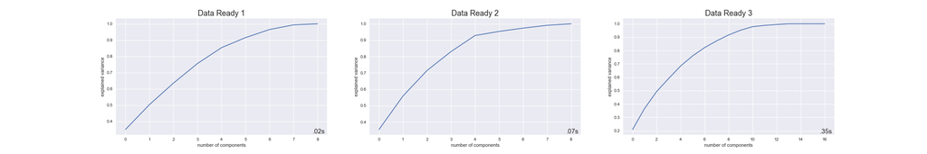

Dari hasil plot elbow method di atas telah didapatkan number of components yang bisa digunakan, dalam kasus ini digunakan pc=8. Tapi untuk visualisasi nanti akan dilakukan setelah data prediksi didapatkan dengan pc=2 karna ingin didapat data 2 dimensi untuk bisa di-visualisasikan.

```python
# pc_1 = 8, pc_2 = 8, pc_3 = 8

pc = 8
pca_scale = PCA(pc, random_state=1)
dfready_scale_pca_1 = pca_scale.fit_transform(dfready_scale_1)
dfready_scale_pca_2 = pca_scale.fit_transform(dfready_scale_2)
dfready_scale_pca_3 = pca_scale.fit_transform(dfready_scale_3)

# dfready_scale_pca.shape
```

```
time: 2.01 s
```

## Anomaly Detection

```python
# Anomaly Detection
ocsvm_1 = svm.OneClassSVM(nu=0.1)
rocov_1 = EllipticEnvelope(random_state=1)
isofor_1 = IsolationForest(random_state=1)

ocsvm_2 = svm.OneClassSVM(nu=0.1)
rocov_2 = EllipticEnvelope(random_state=1)
isofor_2 = IsolationForest(random_state=1)

ocsvm_3 = svm.OneClassSVM(nu=0.1)
rocov_3 = EllipticEnvelope(random_state=1)
isofor_3 = IsolationForest(random_state=1)
```

```
time: 1.99 ms
```

### Model Training

Melakukan training data dengan model yang digunakan.

```python
ocsvm_1.fit(dfready_scale_pca_1)
rocov_1.fit(dfready_scale_pca_1)
isofor_1.fit(dfready_scale_pca_1)

ocsvm_2.fit(dfready_scale_pca_2)
rocov_2.fit(dfready_scale_pca_2)
isofor_2.fit(dfready_scale_pca_2)

ocsvm_3.fit(dfready_scale_pca_3)
rocov_3.fit(dfready_scale_pca_3)
isofor_3.fit(dfready_scale_pca_3)
```

```
IsolationForest(random_state=1)
```

```
time: 23min 39s
```

Simpan ke dalam file untuk kebutuhan analisa lanjutan

```python
dump(ocsvm_1, 'dataset/ocsvm_1.joblib')
dump(rocov_1, 'dataset/rocov_1.joblib')
dump(isofor_1, 'dataset/isofor_1.joblib')

dump(ocsvm_2, 'dataset/ocsvm_2.joblib')
dump(rocov_2, 'dataset/rocov_2.joblib')
dump(isofor_2, 'dataset/isofor_2.joblib')

dump(ocsvm_3, 'dataset/ocsvm_3.joblib')
dump(rocov_3, 'dataset/rocov_3.joblib')
dump(isofor_3, 'dataset/isofor_3.joblib')
```

```
['dataset/isofor_3.joblib']
```

```
time: 680 ms
```

### Model Test

Fungsi decision_function untuk melihat score secara real, jika nilai score anomali semakin minus maka semakin anomali.

```python
ocsvm_1 = load('dataset/ocsvm_1.joblib')
rocov_1 = load('dataset/rocov_1.joblib')
isofor_1 = load('dataset/isofor_1.joblib')

ocsvm_2 = load('dataset/ocsvm_2.joblib')
rocov_2 = load('dataset/rocov_2.joblib')
isofor_2 = load('dataset/isofor_2.joblib')

ocsvm_3 = load('dataset/ocsvm_3.joblib')
rocov_3 = load('dataset/rocov_3.joblib')
isofor_3 = load('dataset/isofor_3.joblib')
```

```
time: 323 ms
```

```python
score_rocov_1 = rocov_1.decision_function(dfready_scale_pca_1)
score_ocsvm_1 = ocsvm_1.decision_function(dfready_scale_pca_1)
score_isofor_1 = isofor_1.decision_function(dfready_scale_pca_1)

score_rocov_2 = rocov_2.decision_function(dfready_scale_pca_2)
score_ocsvm_2 = ocsvm_2.decision_function(dfready_scale_pca_2)
score_isofor_2 = isofor_2.decision_function(dfready_scale_pca_2)

score_rocov_3 = rocov_3.decision_function(dfready_scale_pca_3)
score_ocsvm_3 = ocsvm_3.decision_function(dfready_scale_pca_3)
score_isofor_3 = isofor_3.decision_function(dfready_scale_pca_3)
```

```
time: 2min 55s
```

```python
# Membuat prediksi dari masing-masing model
pred_rocov_1 = rocov_1.predict(dfready_scale_pca_1)
pred_ocsvm_1 = ocsvm_1.predict(dfready_scale_pca_1)
pred_isofor_1 = isofor_1.predict(dfready_scale_pca_1)

pred_rocov_2 = rocov_2.predict(dfready_scale_pca_2)
pred_ocsvm_2 = ocsvm_2.predict(dfready_scale_pca_2)
pred_isofor_2 = isofor_2.predict(dfready_scale_pca_2)

pred_rocov_3 = rocov_3.predict(dfready_scale_pca_3)
pred_ocsvm_3 = ocsvm_3.predict(dfready_scale_pca_3)
pred_isofor_3 = isofor_3.predict(dfready_scale_pca_3)
```

```
time: 2min 53s
```

```python
# Simpan index dimana anomali data ditangkap
idx_rocov_1 = np.where(pred_rocov_1 == -1)
idx_ocsvm_1 = np.where(pred_ocsvm_1 == -1)
idx_isofor_1 = np.where(pred_isofor_1 == -1)

idx_rocov_2 = np.where(pred_rocov_2 == -1)
idx_ocsvm_2 = np.where(pred_ocsvm_2 == -1)
idx_isofor_2 = np.where(pred_isofor_2 == -1)

idx_rocov_3 = np.where(pred_rocov_3 == -1)
idx_ocsvm_3 = np.where(pred_ocsvm_3 == -1)
idx_isofor_3 = np.where(pred_isofor_3 == -1)
```

```
time: 4.95 ms
```

```python
np.where(pred_rocov_1 == -1)
np.where(pred_ocsvm_1 == -1)
np.where(pred_isofor_1 == -1)
```

```
(array([    2,     7,    11, ..., 44099, 44100, 44101], dtype=int64),)
```

```
time: 1.96 ms
```

### Prediction

Prediksi dan dapatkan kira-kira data apa saja yang terindikasi fraudulent. Berikut adalah gambaran hasil yang diberikan (dari data ready)

```python
data_predict_svm_1 = data_ready_1.iloc[idx_ocsvm_1[0],:]
data_predict_svm_2 = data_ready_2.iloc[idx_ocsvm_2[0],:]
data_predict_svm_3 = data_ready_3.iloc[idx_ocsvm_3[0],:]

dump(data_predict_svm_1, 'dataset/data_predict_svm_1.joblib')
dump(data_predict_svm_2, 'dataset/data_predict_svm_2.joblib')
dump(data_predict_svm_3, 'dataset/data_predict_svm_3.joblib')
```

```
['dataset/data_predict_svm_3.joblib']
```

```
time: 75.8 ms
```

```python
data_predict_cov_1 = data_ready_1.iloc[idx_rocov_1[0],:]
data_predict_cov_2 = data_ready_2.iloc[idx_rocov_2[0],:]
data_predict_cov_3 = data_ready_3.iloc[idx_rocov_3[0],:]

dump(data_predict_cov_1, 'dataset/data_predict_cov_1.joblib')
dump(data_predict_cov_2, 'dataset/data_predict_cov_2.joblib')
dump(data_predict_cov_3, 'dataset/data_predict_cov_3.joblib')
```

```
['dataset/data_predict_cov_3.joblib']
```

```
time: 52.1 ms
```

```python
data_predict_isofor_1 = data_ready_1.iloc[idx_isofor_1[0],:]
data_predict_isofor_2 = data_ready_2.iloc[idx_isofor_2[0],:]
data_predict_isofor_3 = data_ready_3.iloc[idx_isofor_3[0],:]

dump(data_predict_isofor_1, 'dataset/data_predict_isofor_1.joblib')
dump(data_predict_isofor_2, 'dataset/data_predict_isofor_2.joblib')
dump(data_predict_isofor_3, 'dataset/data_predict_isofor_3.joblib')
```

```
['dataset/data_predict_isofor_3.joblib']
```

```
time: 46.9 ms
```

### 2d Visualization

Lalu interpretasikan (dan cocokkan) data-data yang anomali dari hasil reduksi dimensi menggunakan visualisasi plotly berikut :

```python
df1 = pd.DataFrame(dfready_scale_pca_1,columns=['pc1','pc2','pc3','pc4','pc5','pc6','pc7','pc8'],index=data_ready_1.index)
df2 = pd.DataFrame(dfready_scale_pca_2,columns=['pc1','pc2','pc3','pc4','pc5','pc6','pc7','pc8'],index=data_ready_2.index)
df3 = pd.DataFrame(dfready_scale_pca_3,columns=['pc1','pc2','pc3','pc4','pc5','pc6','pc7','pc8'],index=data_ready_3.index)
```

```
time: 2.95 ms
```

```python
pc = 2
pca_scale = PCA(pc, random_state=1)
dfready_pca_1 = pca_scale.fit_transform(df1)
dfready_pca_2 = pca_scale.fit_transform(df2)
dfready_pca_3 = pca_scale.fit_transform(df3)

# dfready_tsne_1 = TSNE(n_components=pc).fit_transform(df1)
# dfready_tsne_2 = TSNE(n_components=pc).fit_transform(df2)
# dfready_tsne_3 = TSNE(n_components=pc).fit_transform(df3)

# dfready_tsne_1 = TSNE(n_components=pc).fit_transform(dfready_scale_1)
# dfready_tsne_2 = TSNE(n_components=pc).fit_transform(dfready_scale_2)
# dfready_tsne_3 = TSNE(n_components=pc).fit_transform(dfready_scale_3)
```

```
time: 1.07 s
```

```python
df_tsne_1 = pd.DataFrame(dfready_pca_1,columns=['pc1','pc2'],index=data_ready_1.index)
df_tsne_2 = pd.DataFrame(dfready_pca_2,columns=['pc1','pc2'],index=data_ready_2.index)
df_tsne_3 = pd.DataFrame(dfready_pca_3,columns=['pc1','pc2'],index=data_ready_3.index)

# df_tsne_1 = pd.DataFrame(dfready_tsne_1,columns=['pc1','pc2'],index=data_ready_1.index)
# df_tsne_2 = pd.DataFrame(dfready_tsne_2,columns=['pc1','pc2'],index=data_ready_2.index)
# df_tsne_3 = pd.DataFrame(dfready_tsne_3,columns=['pc1','pc2'],index=data_ready_3.index)
```

```
time: 3.99 ms
```

```python
# Join data hasil scaling di atas dengan data_ready yang di atas.
df_1 = df_tsne_1.join(data_ready_1)
df_2 = df_tsne_2.join(data_ready_2)
df_3 = df_tsne_3.join(data_ready_3)
```

```
time: 473 ms
```

```python
df_pca_1 = df_tsne_1.copy()
df_pca_2 = df_tsne_2.copy()
df_pca_3 = df_tsne_3.copy()
```

```
time: 12 ms
```

```python
# Menggunakan Data Ready 1
df = df_1.copy()
fig = px.scatter(df, x="pc1", y="pc2", hover_data=[df.index.get_level_values(0),
    df.index,
    'pc1','pc2', 'total_call', 'total_duration'])
# fig.show()
plotly.offline.plot(fig, filename='assets/plt_data_ready_1.html', image='png', auto_open=True, output_type='file', image_width=800, image_height=600, validate=False)
```

```
'assets/plt_data_ready_1.html'
```

```
time: 1.6 s
```

Menggunakan data ready 1 maka akan menghasilkan plot seperti berikut :

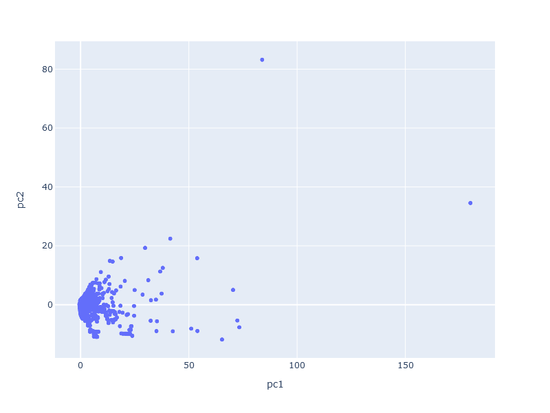

```python
#Menggunakan Data Ready 2
df = df_2.copy()
fig = px.scatter(df, x="pc1", y="pc2", hover_data=[df.index.get_level_values(0),
    df.index.get_level_values(1),
    'pc1','pc2', 'total_call', 'total_duration'])
# fig.show()
plotly.offline.plot(fig, filename='assets/plt_data_ready_2.html', image='png', auto_open=True, output_type='file', image_width=800, image_height=600, validate=False)
```

```
'assets/plt_data_ready_2.html'
```

```
time: 6.14 s
```

Menggunakan data ready 2 maka akan menghasilkan plot seperti berikut :

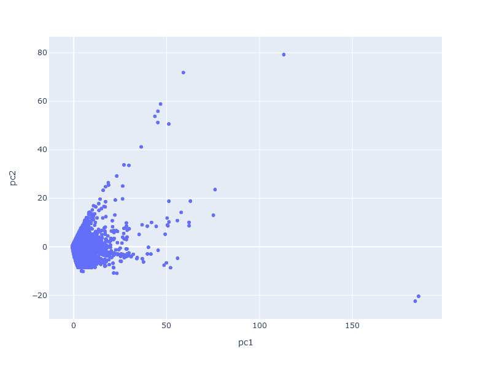

```python
#Menggunakan Data Ready 3
df = df_3.copy()
fig = px.scatter(df, x="pc1", y="pc2", hover_data=[df.index.get_level_values(0),
    df.index.get_level_values(1),
    df.index.get_level_values(2),
    'pc1','pc2', 'total_call', 'total_duration'])
# fig.show()
plotly.offline.plot(fig, filename='assets/plt_data_ready_3.html', image='png', auto_open=True, output_type='file', image_width=800, image_height=600, validate=False)
```

```
'assets/plt_data_ready_3.html'
```

```
time: 10.8 s
```

Menggunakan data ready 3 maka akan menghasilkan plot seperti berikut :

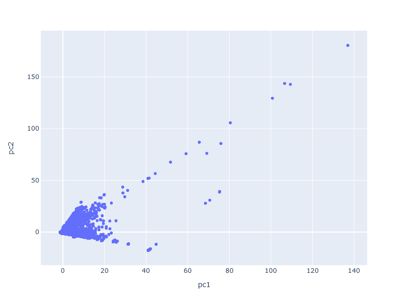

Performa masing-masing model **Anomaly Detection** seperti gambar berikut :

```python
# Dengan menggunakan data ready 1
rcParams['figure.figsize'] = 30, 5
anomaly_algorithms = [('One Class SVM', ocsvm_1), # model one class svm disimpan dengan nama `ocsvm`
                      ('Robust Covariance',rocov_1),
                      ('Isolation Forest',isofor_1)]
plot_num = 1
xx, yy = np.meshgrid(np.linspace(-10, 100, 300),np.linspace(-20, 40, 200))
for name, algorithm in anomaly_algorithms:
    model = algorithm
    t0 = time.time()
    model.fit(df_pca_1)
    t1 = time.time()
    plt.subplot(1, len(anomaly_algorithms), plot_num)

    plt.title(name, size=18)

    # fit the data and tag outliers
    y_pred = algorithm.predict(df_pca_1)

    # plot the levels lines and the points
    Z = algorithm.predict(np.c_[xx.ravel(), yy.ravel()])
    Z = Z.reshape(xx.shape)
    plt.contour(xx, yy, Z, levels=[0], linewidths=2, colors='black')

    colors = np.array(['#377eb8', '#ff7f00'])
    plt.scatter(df_pca_1['pc1'], df_pca_1['pc2'], s=10, color=colors[(y_pred + 1) // 2])
    plt.xlim(-20, 100)
    plt.ylim(-20, 50)
    plt.xticks(())
    plt.yticks(())
    plt.text(.99, .01, ('%.2fs' % (t1 - t0)).lstrip('0'),
             transform=plt.gca().transAxes, size=15,
             horizontalalignment='right')
    plot_num+=1

# plt.show()
plt.savefig('assets/plt_anomaly_1.png')
```

```
time: 1.02 ms
```

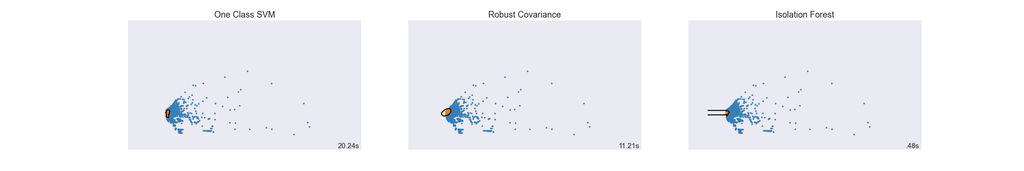

```python
# Dengan menggunakan data ready 2
rcParams['figure.figsize'] = 30, 5
anomaly_algorithms = [('One Class SVM', ocsvm_2), # model one class svm disimpan dengan nama `ocsvm`
                      ('Robust Covariance',rocov_2),
                      ('Isolation Forest',isofor_2)]
plot_num = 1
xx, yy = np.meshgrid(np.linspace(-10, 100, 300),np.linspace(-20, 40, 200))
for name, algorithm in anomaly_algorithms:
    model = algorithm
    t0 = time.time()
    model.fit(df_pca_2)
    t1 = time.time()
    plt.subplot(1, len(anomaly_algorithms), plot_num)

    plt.title(name, size=18)

    # fit the data and tag outliers
    y_pred = algorithm.predict(df_pca_2)

    # plot the levels lines and the points
    Z = algorithm.predict(np.c_[xx.ravel(), yy.ravel()])
    Z = Z.reshape(xx.shape)
    plt.contour(xx, yy, Z, levels=[0], linewidths=2, colors='black')

    colors = np.array(['#377eb8', '#ff7f00'])
    plt.scatter(df_pca_2['pc1'], df_pca_2['pc2'], s=10, color=colors[(y_pred + 1) // 2])
    plt.xlim(-20, 100)
    plt.ylim(-20, 50)
    plt.xticks(())
    plt.yticks(())
    plt.text(.99, .01, ('%.2fs' % (t1 - t0)).lstrip('0'),
             transform=plt.gca().transAxes, size=15,
             horizontalalignment='right')
    plot_num+=1

# plt.show()
plt.savefig('assets/plt_anomaly_2.png')
```

[output not shown]

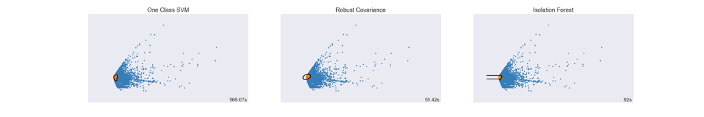

```python
# Dengan menggunakan data ready 3
rcParams['figure.figsize'] = 30, 5
anomaly_algorithms = [('One Class SVM', ocsvm_3), # model one class svm disimpan dengan nama `ocsvm`
                      ('Robust Covariance',rocov_3),
                      ('Isolation Forest',isofor_3)]
plot_num = 1
xx, yy = np.meshgrid(np.linspace(-10, 100, 300),np.linspace(-20, 40, 200))
for name, algorithm in anomaly_algorithms:
    model = algorithm
    t0 = time.time()
    model.fit(df_pca_3)
    t1 = time.time()
    plt.subplot(1, len(anomaly_algorithms), plot_num)

    plt.title(name, size=18)

    # fit the data and tag outliers
    y_pred = algorithm.predict(df_pca_3)

    # plot the levels lines and the points
    Z = algorithm.predict(np.c_[xx.ravel(), yy.ravel()])
    Z = Z.reshape(xx.shape)
    plt.contour(xx, yy, Z, levels=[0], linewidths=2, colors='black')

    colors = np.array(['#377eb8', '#ff7f00'])
    plt.scatter(df_pca_3['pc1'], df_pca_3['pc2'], s=10, color=colors[(y_pred + 1) // 2])
    plt.xlim(-20, 100)
    plt.ylim(-20, 50)
    plt.xticks(())
    plt.yticks(())
    plt.text(.99, .01, ('%.2fs' % (t1 - t0)).lstrip('0'),
             transform=plt.gca().transAxes, size=15,
             horizontalalignment='right')
    plot_num+=1

# plt.show()
plt.savefig('assets/plt_anomaly_3.png')
```

[output not shown]

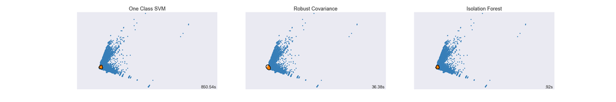

# Evaluasi

Bandingkan dengan dataframe **fraud** yang berupa data fraud berdasarkan rule base untuk masing-masing hasil prediksi. Cek mana yang paling cocok atau paling banyak menangkap nomor telepon fraud yang sama.

```python
fraud.set_index(['source_num'], inplace=True)
```

```
time: 4.96 ms
```

```python
data_predict_svm_1 = load('dataset/data_predict_svm_1.joblib')
data_predict_cov_1 = load('dataset/data_predict_cov_1.joblib')
data_predict_isofor_1 = load('dataset/data_predict_isofor_1.joblib')

data_predict_svm_2 = load('dataset/data_predict_svm_2.joblib')
data_predict_cov_2 = load('dataset/data_predict_cov_2.joblib')
data_predict_isofor_2 = load('dataset/data_predict_isofor_2.joblib')

data_predict_svm_3 = load('dataset/data_predict_svm_3.joblib')
data_predict_cov_3 = load('dataset/data_predict_cov_3.joblib')
data_predict_isofor_3 = load('dataset/data_predict_isofor_3.joblib')
```

```
time: 3.41 s
```

```python
# Cek jumlah nomor telepon unik untuk masing-masing dataframe.
print(fraud.shape)
print(data_predict_svm_1.shape)
print(data_predict_cov_1.shape)
print(data_predict_isofor_1.shape)
```

```
(149, 11)
(4225, 9)
(4423, 9)
(5390, 9)
time: 973 µs
```

```python
# Cek jumlah nomor telepon unik untuk masing-masing dataframe.
print(fraud.index.nunique())
print(data_predict_svm_1.index.get_level_values(0).nunique())
print(data_predict_cov_1.index.get_level_values(0).nunique())
print(data_predict_isofor_1.index.get_level_values(0).nunique())
```

```
69
4225
4423
5390
time: 27.7 ms
```

```python
# Cek jumlah nomor telepon unik untuk masing-masing dataframe.
print(fraud.index.nunique())
print(data_predict_isofor_1.index.get_level_values(0).nunique())
print(data_predict_isofor_2.index.get_level_values(0).nunique())
print(data_predict_isofor_3.index.get_level_values(0).nunique())
```

```
69
5390
3977
5636
time: 3.96 ms
```

Merge (union) data dari masing-masing hasil model prediksi untuk menyaring data anomaly lebih banyak.

```python
data_merge_svm = data_predict_svm_1.merge(data_predict_svm_2, how='outer', on=['source_num'])
data_merge_svm = data_merge_svm.merge(data_predict_svm_3, how='outer', on=['source_num'])
print(data_merge_svm.index.nunique())

data_merge_cov = data_predict_cov_1.merge(data_predict_cov_2, how='outer', on=['source_num'])
data_merge_cov = data_merge_cov.merge(data_predict_cov_3, how='outer', on=['source_num'])
print(data_merge_cov.index.nunique())

data_merge_isofor = data_predict_isofor_1.merge(data_predict_isofor_2, how='outer', on=['source_num'])
data_merge_isofor = data_merge_isofor.merge(data_predict_isofor_3, how='outer', on=['source_num'])
print(data_merge_isofor.index.nunique())
```

```
15176
15239
9613
time: 492 ms
```

Lanjutkan dengan melakukan komparasi (irisan) data nomor telepon asal yang unik terhadap data fraud berdasarkan rule base.

```python
compare_svm = data_merge_svm.merge(fraud, how='inner', on=['source_num'])
compare_svm.index.nunique()
```

```
42
```

```
time: 72.9 ms
```

```python
compare_cov = data_merge_cov.merge(fraud, how='inner', on=['source_num'])
compare_cov.index.nunique()
```

```
42
```

```
time: 19.8 ms
```

```python
compare_isofor = data_merge_isofor.merge(fraud, how='inner', on=['source_num'])
compare_isofor.index.nunique()
```

```
40
```

```
time: 39.9 ms
```

# Kesimpulan

Dari hasil model **Anomaly Detection** di atas dapat dilihat **Isolation Forest** lebih sedikit menangkap anomali data. Dan jumlahnya tidak terpaut jauh pada saat dilakukan union data dari ke-3 data ready dibandingkan dengan menggunakan model lain yang terpaut jauh. Akan tetapi ketika menangkap kecocokan data dengan data fraud berdasarkan rule base lebih sedikit dibanding model lainnya.

Untuk itu perlu dilakukan pengecekan lanjutan terhadap data prediksi ini untuk mengetahui data fraud yang sesungguhnya, karna data prediksi ini bukan menandakan fraud yang sesungguhnya.